# Developing SOM + Hierarchical Clustering + Connectivity Constrains

OEB

June 29, 2017

# 1 Scope

Self-Organizing Maps(SOM) are widely used for customer and gene clustering. Solutions in R are not very accessible due to lack of documentation and inefficient clustering methods that do not lead to connected clusters on the SOM. We will try to develop a generic method that allows clustering of any dataset with contineous and categorical variables and results in connected clusters on the SOM.

# 2 Background

Self organizing maps area great way to organize your multidimensional dataset in a two dimensional space using a neural network.

The concept on how that works is best explained in those two videos

- [Video 1](https://www.youtube.com/watch?v=HKj2ASG0DKQ#t=476.297807)
- [video 2](https://www.youtube.com/watch?v=wRcnNyoXm_M#t=699.986893)

A difficulty with clustering methods relying on a distance matrix ist that it is very memory instensive. A dataset with 50k observations lie the diamond dataset will result in a 50kx50k distance matrix. The R packages implementing SOMs do not use distance matrixes even though using the same distance measures and thus can also cluster large datasets.

# 3 Present R implementation and Ressources

To my knowledge the `kohonen` package is the best developed R package implementing the SOM algorithm. There is another package called `som` but the reference manual on cran dates back to [June 2016](https://cran.r-project.org/web/packages/som/index.html), while the documentation for the `kohonen` package was updated in [March 2017](https://cran.r-project.org/web/packages/kohonen/index.html). Both packages do not come with a vignette but an in-depth [blog post](https://www.r-bloggers.com/self-organising-maps-for-customer-segmentation-using-r/%20http://en.proft.me/2016/11/29/modeling-self-organising-maps-r/) on the functionalities of the `kohonen` package is available.

We therefore will focus on the `kohonen` package

# 4 Difficulties

The [blog post](https://www.r-bloggers.com/self-organising-maps-for-customer-segmentation-using-r/%20http://en.proft.me/2016/11/29/modeling-self-organising-maps-r/) does not explain how to implement categorical data. The method of clustering of the SOM also leads to unconnected clusters.

# 5 Approach

We will work with the `kohonen` package documentation in order to get it to work for mixed (contineous and categorical) datasets.

```r
require(tidyverse)
require(magrittr)
```

```r
setwd('C:\\Users\\erbla\\OneDrive\\R\\SOM')

#source('hclust R Version.R')

# Colour palette definition
library(RColorBrewer)
n <- 60
qual_col_pals = brewer.pal.info[brewer.pal.info$category == 'qual',]
col_vector = unlist(mapply(brewer.pal, qual_col_pals$maxcolors, rownames(qual_col_pals)))
```

```r
# data = ISLR::Auto %>%
#   select(-name) %>%
#   mutate(origin = as.factor(origin) )

data = diamonds


map_dimension = 20

n_iterations = 1000

recalculate_map = T

recalculate_no_clusters = T
```

## 5.1 Data Preparation

The `kohonen::supersom` accepts multilayered datasets, a named `list` in which each element consists of a `matrix` with an equal number of observations(rows). The function lets us specify which layer to include and lets us chose difference distance measures for each layer.

We further find the function `kohonen::classvec2classmat` and `kohonen::classmat2classvec` which turns a factor column vector into a class matrix and vice versa. Differently from functions that convert a factor column vector into dummy variables, this function adds a single binary column per factor level.

Hence we will convert our dataframe int a named list creating an extra layer for each factor variable. We will use euclidean distance for contineous data and tanimato distance for the factor layers.

We do have the option of assigning different weights to the single layers. It might seem reasonable to assign more weight to the layers that represent more variables. In practice however it seems to me that the training is asynchronous. The neurons will train more strongly on the layer containing all the numerical variables. Aggregating much faster than based on the other layers. In the end this will lead to clusters where the borders are definded by the weaker weighted layers and inside of them we find a aggregated nuclei of observations with high numerical values.

Thus you will find the part of the code where I weighted the layers commented out.

```r
# prepare data

numerics = summarise_all( data, is.numeric ) %>%
  as.logical()

factors = names(data)%>%
  .[!numerics]

numerics = names(data)%>%
  .[numerics]



data_list = list()
distances = vector()

for (fac in factors){

  data_list[[fac]] = kohonen::classvec2classmat( data[[fac]] )

  distances = c(distances, 'tanimoto')

}

data_list[['numerics']] = scale(data[,numerics])
distances = c( distances, 'euclidean')

str(data_list)
```

```
## List of 4
##  $ cut     : num [1:53940, 1:5] 0 0 0 0 0 0 0 0 1 0 ...
##   ..- attr(*, "dimnames")=List of 2
##   .. ..$ : NULL
##   .. ..$ : chr [1:5] "Fair" "Good" "Very Good" "Premium" ...
##  $ color   : num [1:53940, 1:7] 0 0 0 0 0 0 0 0 0 0 ...
##   ..- attr(*, "dimnames")=List of 2
##   .. ..$ : NULL
##   .. ..$ : chr [1:7] "D" "E" "F" "G" ...
##  $ clarity : num [1:53940, 1:8] 0 0 0 0 0 0 0 0 0 0 ...
##   ..- attr(*, "dimnames")=List of 2
##   .. ..$ : NULL
##   .. ..$ : chr [1:8] "I1" "SI2" "SI1" "VS2" ...
##  $ numerics: num [1:53940, 1:7] -1.2 -1.24 -1.2 -1.07 -1.03 ...
##   ..- attr(*, "dimnames")=List of 2
##   .. ..$ : NULL
##   .. ..$ : chr [1:7] "carat" "depth" "table" "price" ...
##   ..- attr(*, "scaled:center")= Named num [1:7] 0.798 61.749 57.457 3932.8 5.731 ...
##   .. ..- attr(*, "names")= chr [1:7] "carat" "depth" "table" "price" ...
##   ..- attr(*, "scaled:scale")= Named num [1:7] 0.474 1.433 2.234 3989.44 1.122 ...
##   .. ..- attr(*, "names")= chr [1:7] "carat" "depth" "table" "price" ...
```

```r
names(data_list)
```

```
## [1] "cut"      "color"    "clarity"  "numerics"
```

```r
distances
```

```
## [1] "tanimoto"  "tanimoto"  "tanimoto"  "euclidean"
```

```r
# weight_layers = c( length(numerics), rep( 1, length(factors) ) )
```

## 5.2 SOM

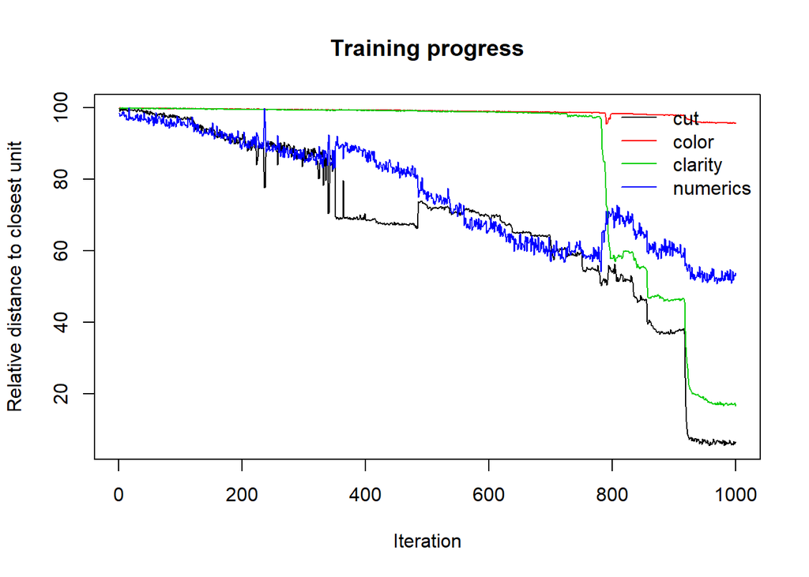

```r
# create a grid onto which the som will be mapped
# we might want to change map dimension in future versions

som_grid = kohonen::somgrid(xdim = map_dimension
                            , ydim=map_dimension
                            , topo="hexagonal")



if(recalculate_map == F & file.exists('som.Rdata') == T){

  load('som.Rdata')

} else{

  m = kohonen::supersom( data_list
                   , grid=som_grid
                   , rlen= n_iterations
                   , alpha = 0.05
                   , whatmap = c(factors, 'numerics')
                   , dist.fcts = distances
                   #, user.weights = weight_layers
                   #, maxNA.fraction = .5
                    )

  save(m, file = 'som.Rdata')

}

plot(m, type="changes")
```

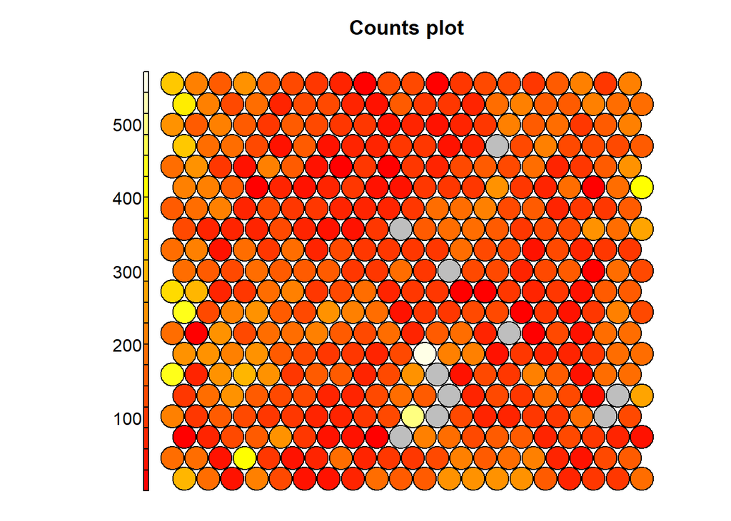

```r
plot(m, type="counts")
```

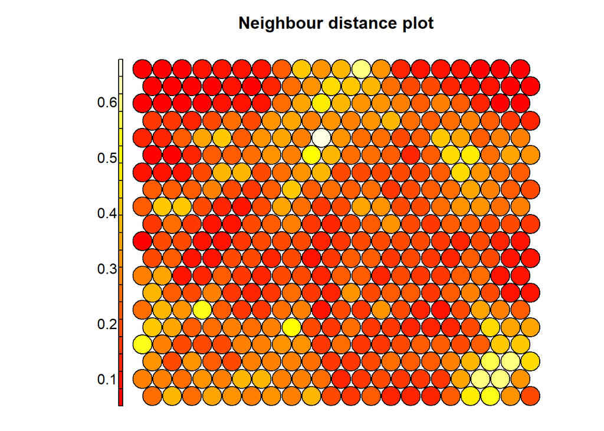

```r
plot(m, type="dist.neighbours")
```

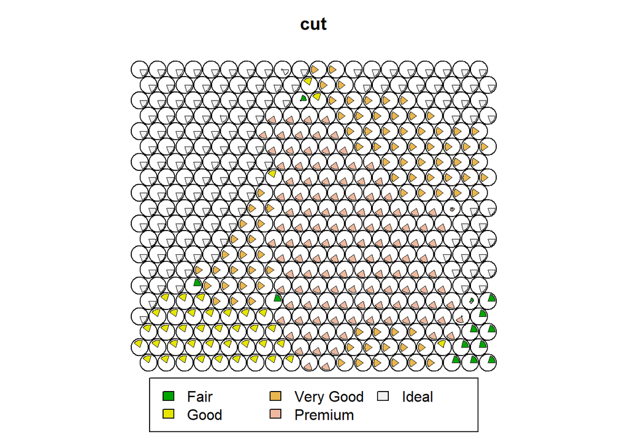

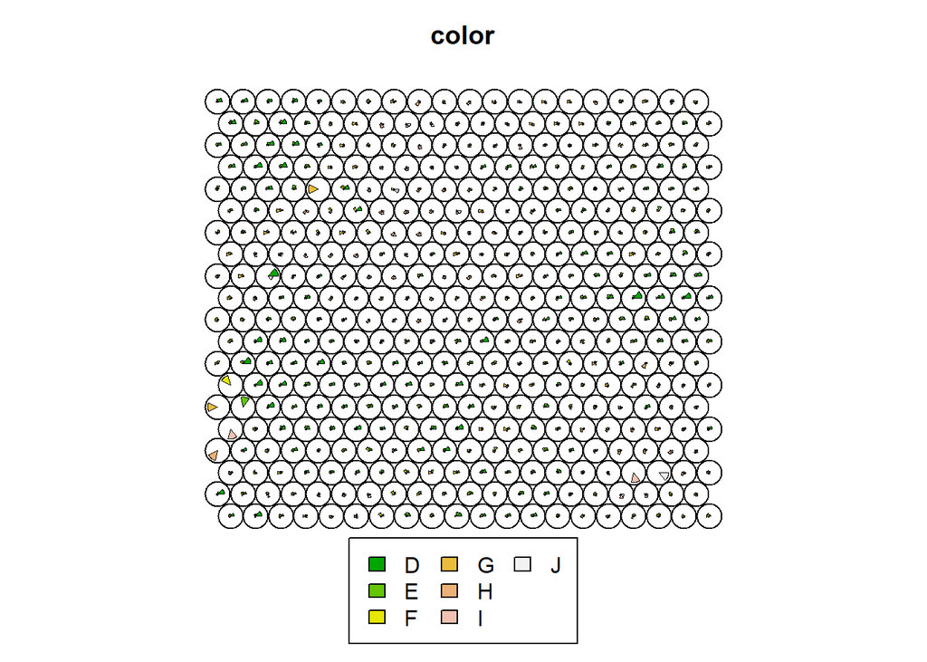

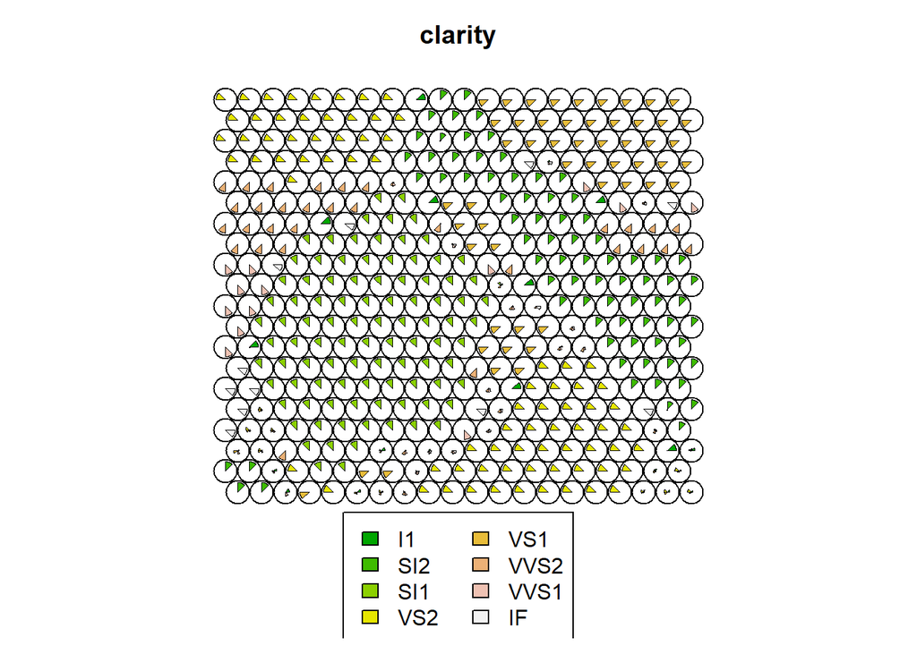

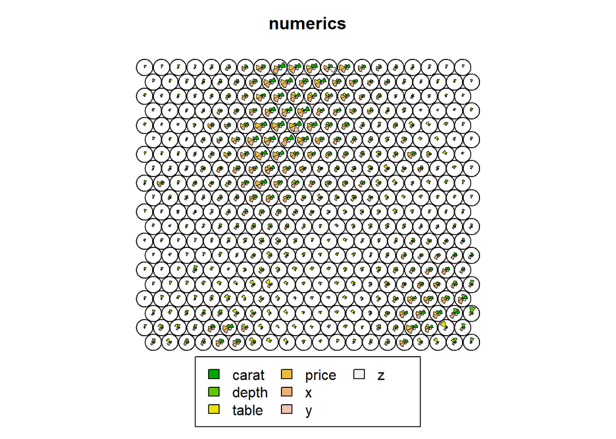

```r
plot(m, type="codes")
```

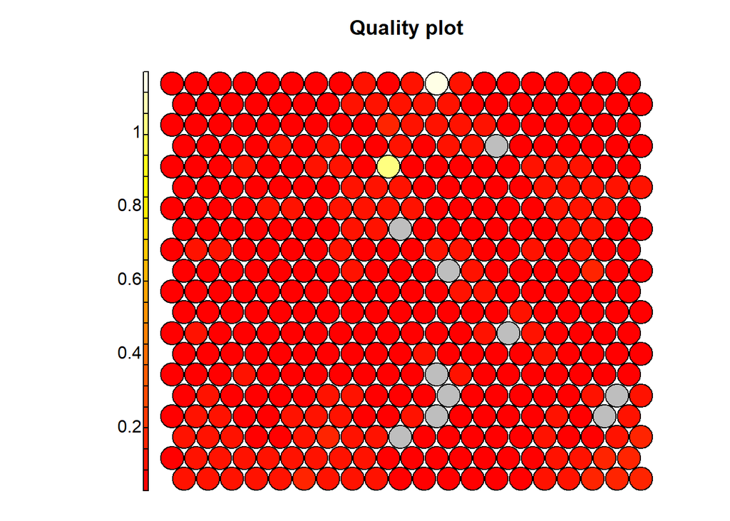

```r
plot(m, type="quality")
```

# 6 Hierarchical Clustering with Connectivity Constains

In order to implement connectivity constrains we have to factor in the distance of each cluster to another cluster on the SOM map. Clacluating distances on a hexagonal map is not trivial, so it comes in handy that the `kohonen` package provides such a function. `kohonen::unit.distances` takes a som grid and returns a distance matrix reflecting the positional distance among clusters on the som grid.

```r
# fuse all layers into one dataframe
codes = tibble( layers = names(m$codes)
                ,codes = m$codes ) %>%
  mutate( codes = purrr::map(codes, as_tibble) ) %>%
  spread( key = layers, value = codes) %>%
  apply(1, bind_cols) %>%
  .[[1]] %>%
  as_tibble()

# generate distance matrix for codes
dist_m = dist(codes) %>%
  as.matrix()

# generate seperate distance matrix for map location

dist_on_map = kohonen::unit.distances(som_grid)


#exponentiate euclidean distance by distance on map
dist_adj = dist_m ^ dist_on_map
```

## 6.1 Determining the optimal number of clusters

There are are plenty of methods to determine the optimal number of clusters, a few of them are explained by the makers of the `factoextra` package on their [website](http://www.sthda.com/english/wiki/determining-the-optimal-number-of-clusters-3-must-known-methods-unsupervised-machine-learning), which also provides an excellent ressource related to clustering methods. We will graphically look at the ellbow, the silhouette and the gap statistics method and the perform an array of other indeces which return a single number as the optimal number of clusters and have them cast a vote. For the latter we will use `Nbclust::Nbclust()`

In my preruns I subjectively find that the `ward.D2` methods seems to deliver the best clustering results on a som map trained with the `diamonds` data set we will therefore start with this method.

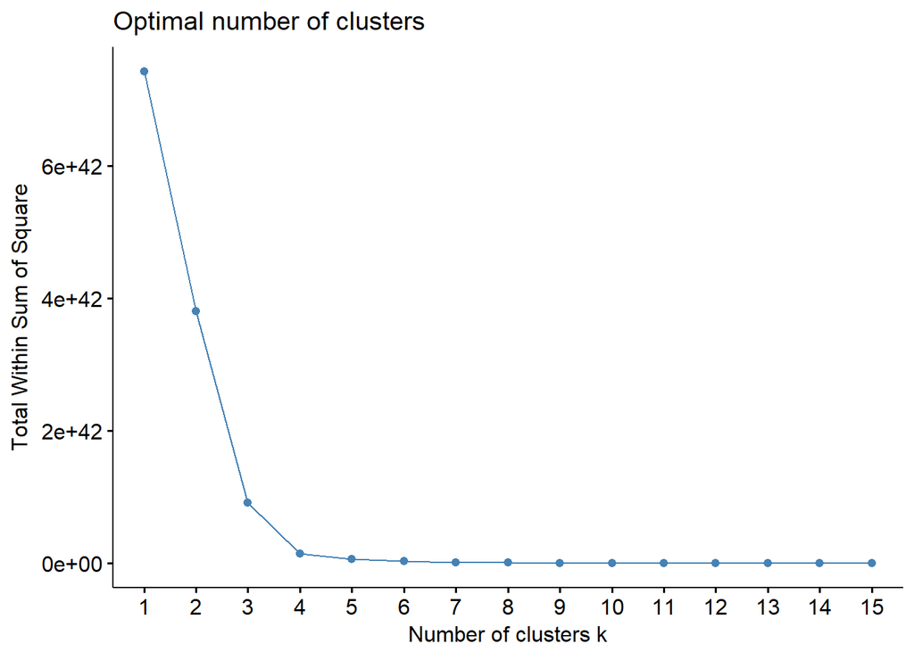

```r
#ellbow method
factoextra::fviz_nbclust(dist_adj
                         , factoextra::hcut
                         , method = "wss"
                         , hc_method = 'ward.D2'
                         , k.max = 15)
```

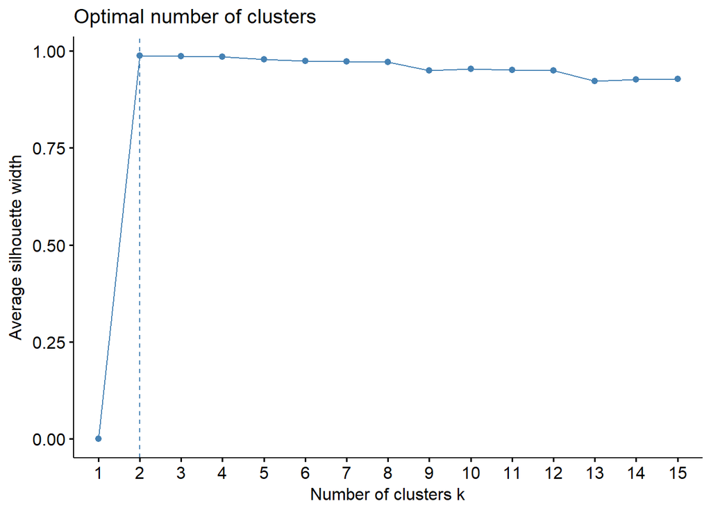

```r
#silhouette method
factoextra::fviz_nbclust(dist_adj
                         , factoextra::hcut
                         , method = "silhouette"
                         , hc_method = "ward.D2"
                         , k.max =  15)
```

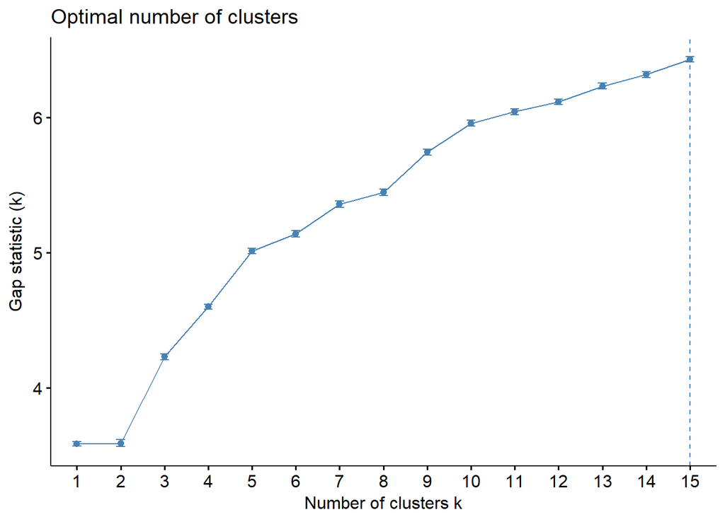

```r
#gap statistic
set.seed(123)
gap_stat = cluster::clusGap(dist_adj
                               , FUN = factoextra::hcut
                               , K.max = 15
                               , B = 50
                               , hc_method = "ward.D2")

factoextra::fviz_gap_stat(gap_stat)
```

```r
# NbClust



# not all of the indexes always work with all distance matrices, especially ours which has been manipulated and represents a mix of numerical and categorical data we therefore will loop through all available indeces and catch all errors.

#hubert and dindex have been removed from list, becuase those are graphical methods
#gap and silhoutte have been removed as well since they are being plotted anyways
indexes = c( "kl", "ch", "hartigan", "ccc", "scott", "marriot", "trcovw", "tracew", "friedman", "rubin", "cindex", "db", "duda", "pseudot2", "beale", "ratkowsky", "ball", "ptbiserial", "frey", "mcclain", "gamma", "gplus", "tau", "dunn", "sdindex",  "sdbw")

if(recalculate_no_clusters == F & file.exists('nbclust.Rdata') == T ){

  load('nbclust.Rdata')

}else{

  results_nb = list()

  safe_nb = purrr::safely(NbClust::NbClust)

  # we will time the execution time of each step
  times = list()

  for(i in 1:length(indexes) ){

  t = lubridate::now()

  nb = safe_nb(as.dist(dist_adj)
                        , distance = "euclidean"
                        , min.nc = 2
                        , max.nc = 15
                        , method = "ward.D2"
                        , index = indexes[i]
                        )

  results_nb[[i]] = nb

  times[[i]]      = lubridate::now()-t

  #print(indexes[i])
  #print(nb$result$Best.nc)

  }

  df_clust = tibble( indexes = indexes
                     , times = times
                     , nb = results_nb) %>%
    mutate( results = purrr::map(nb,'result')
            , error = purrr::map(nb, 'error')
            , is_ok = purrr::map_lgl(error, is_null))

  df_clust_success = df_clust %>%
    filter( is_ok ) %>%
    mutate( names      = purrr::map(results, names)
            ,all_index = purrr::map(results, 'All.index')
            ,best_nc   = purrr::map(results, 'Best.nc')
            ,best_nc   = purrr::map(best_nc, function(x) x[[1]])
            ,is_ok     = !purrr::map_lgl(best_nc, is_null)
            ) %>%
    filter(is_ok) %>%
    mutate( best_nc    = purrr::flatten_dbl(best_nc))

  save(df_clust_success, file = 'nbclust.Rdata')
}
```

```
## [1] "Frey index : No clustering structure in this data set"
```

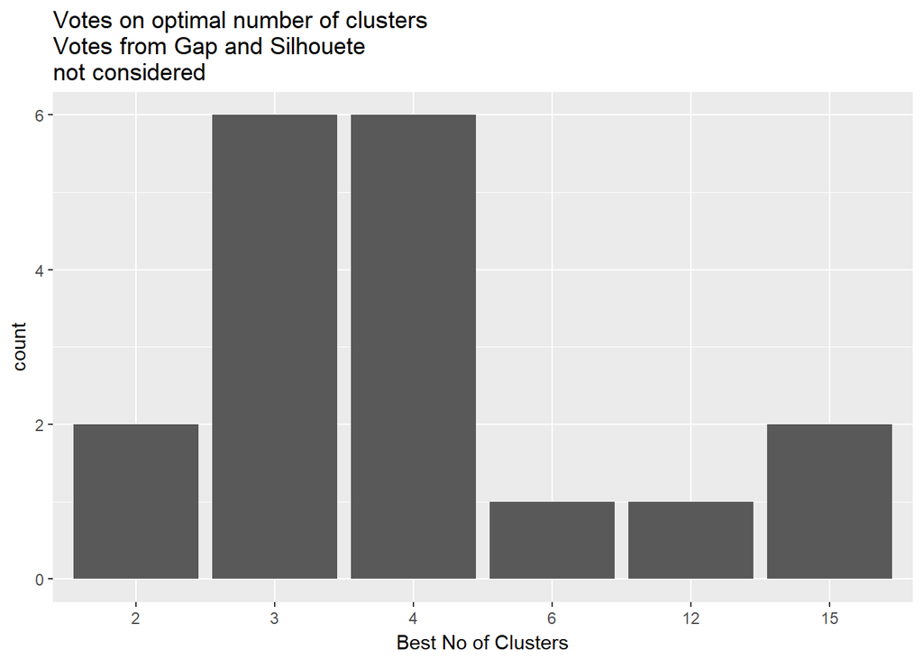

```r
df_clust_success %>%
  filter(!is_null(best_nc) )%>%
ggplot( aes(x = as.factor(best_nc))) +
  geom_bar()+
  labs(title = 'Votes on optimal number of clusters\nVotes from Gap and Silhouete\nnot considered'
       ,x     = 'Best No of Clusters')
```

## 6.2 Hierarchical Clustering

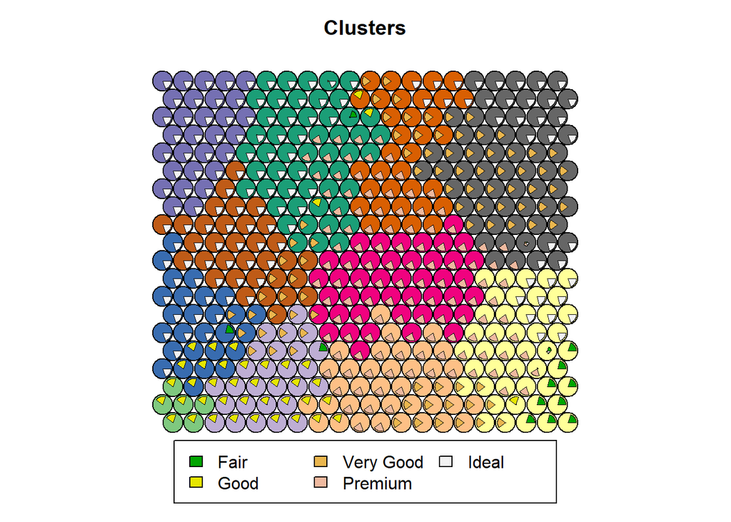

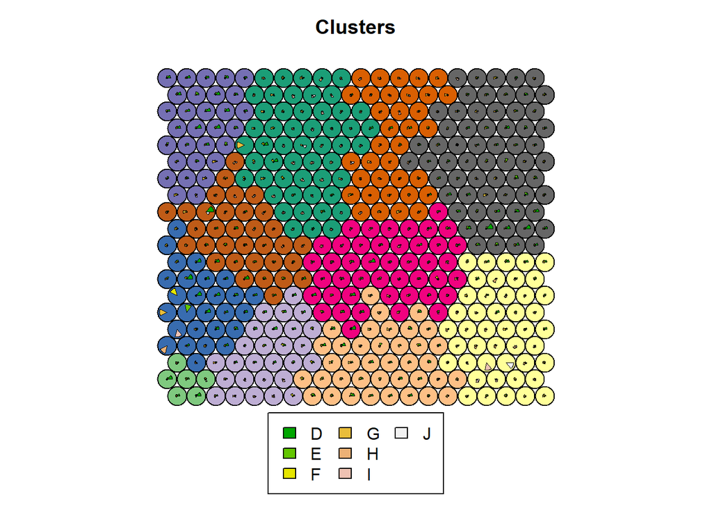

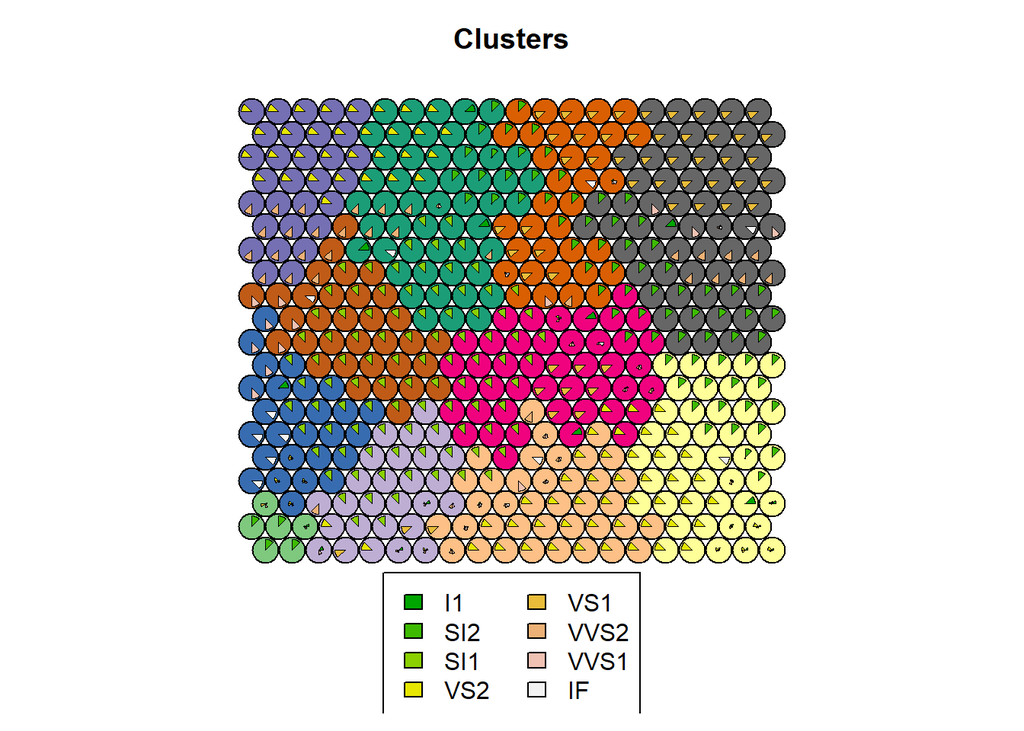

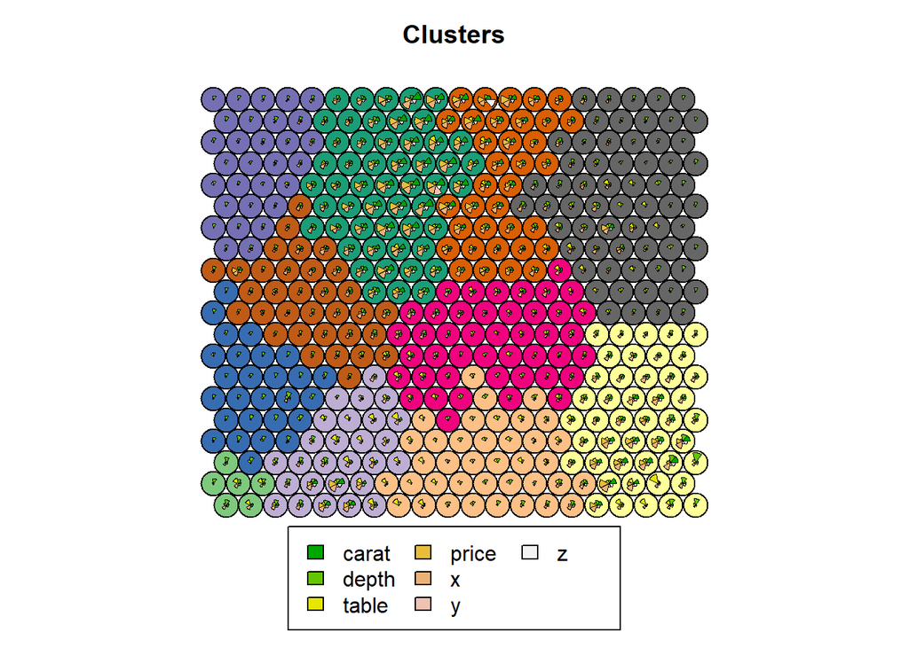

```r
dist_adj =  dist_m ^ dist_on_map

clust_adj = hclust(as.dist(dist_adj), 'ward.D2')


som_cluster_adj = cutree(clust_adj, 11)
plot(m, type="codes", main = "Clusters", bgcol = col_vector[som_cluster_adj], pchs = NA)
```

We find that clustering will not always resolve in a perfectly neighboured clusters. A walkaround could be to manually assign a cluster to hexagons that seem a bit off. However for most downstream calculation this should be irrelevant.

## 6.3 Cluster Summary

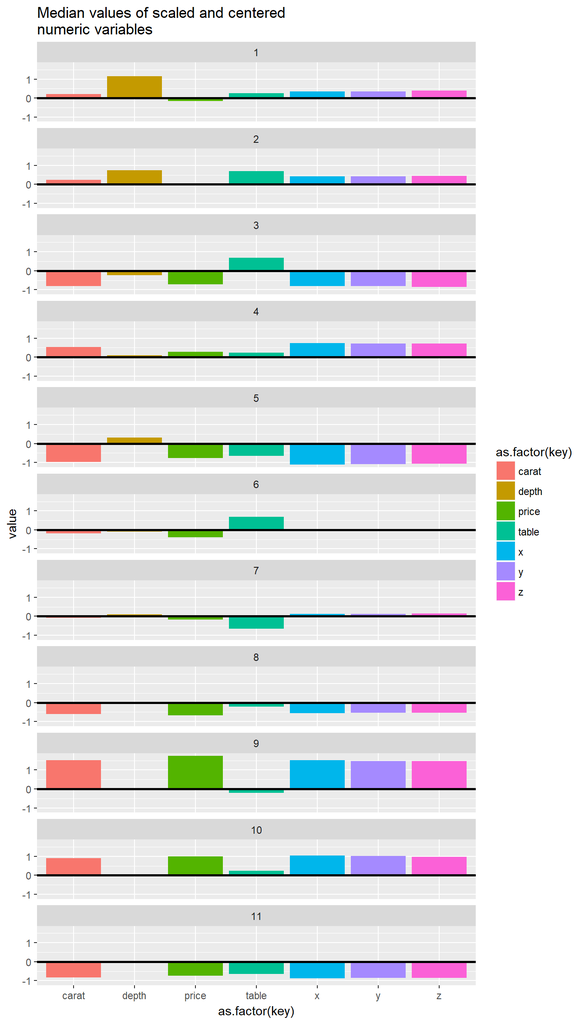

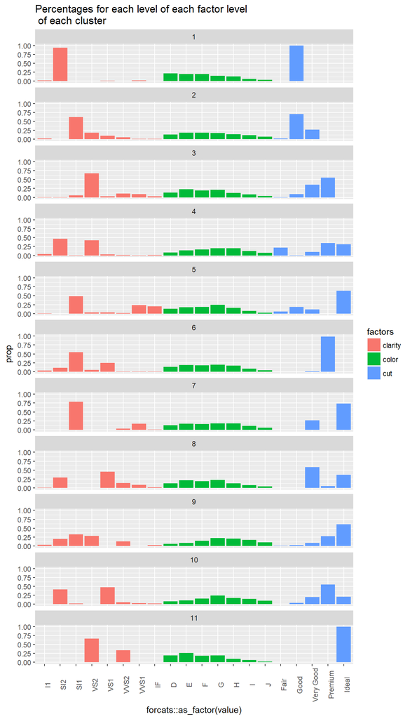

```r
link = tibble( map_loc = names(som_cluster_adj) %>% as.integer()
               ,cluster = som_cluster_adj)

pred = tibble( map_loc = m$unit.classif) %>%
  left_join(link)
data_pred = data %>%
  bind_cols(pred)

# plot numericals absolute values

# d_plot = data_pred %>%
#   as_tibble() %>%
#   select( one_of(numerics), cluster ) %>%
#   gather(key = 'key', value = 'value', one_of(numerics) )
#
# medians = d_plot %>%
#   group_by(key, cluster) %>%
#   summarize_all( median)
#
# ggplot(d_plot, aes(x = as.factor(cluster)
#                    , y = value) ) +
#   geom_violin( aes( fill = as.factor(cluster)) ) +
#   geom_crossbar( data = medians
#                  , mapping = aes(x = as.factor(cluster)
#                                  ,ymin = value
#                                  ,ymax = value)) +
#   facet_wrap(~key
#              , scales = 'free_y'
#              , ncol = 1)+
#   labs(title = 'Absolute Values of\nnumeric variables'
#        )

# plot numericals scaled values

d_plot_scale = data %>%
  select( one_of(numerics) ) %>%
  scale(center = T) %>%
  as_tibble() %>%
  bind_cols(pred) %>%
  gather(key = 'key', value = 'value', one_of(numerics) )

medians = d_plot_scale %>%
  group_by(key, cluster) %>%
  summarize_all( median)


ggplot(medians, aes(x = as.factor(key)
                   , y = value) ) +
  geom_bar( aes( fill = as.factor(key))
            ,stat = 'identity') +
  geom_hline(yintercept = 0
             ,size = 1) +
  facet_wrap(~cluster
             , ncol = 1
             ) +
  labs(title = 'Median values of scaled and centered\nnumeric variables')


# categoricals--------------------------------------------------------

d_plot = data_pred %>%
  as_tibble() %>%
  select( one_of(factors), cluster ) %>%
  gather(key = 'key', value = 'value', one_of(factors) )

# to preserve factor order we have to add a sorting column

d_order = data_pred %>%
  as_tibble() %>%
  select( one_of(factors), cluster ) %>%
  mutate_all( as.integer ) %>%
  gather(key = 'key', value = 'order', one_of(factors) ) %>%
  mutate( order = stringr::str_c(key, order))

d_plot = d_plot %>%
  bind_cols( select(d_order, order) )%>%
  arrange( order ) %>%
  # we have to convert value to factor here
  # ggplot will mess up the order if some
  # facet groups dont have all levels()
  mutate( value = forcats::as_factor(value))

ggplot(d_plot ) +
  geom_bar( aes( x = forcats::as_factor(value)
                , y = ..prop..
                , fill = key
                , group = key)
            )+
  facet_wrap(~ cluster
             ,ncol = 1)+
  labs(title = 'Percentages for each level of each factor level\n of each cluster',
       fill = 'factors')+
  theme(axis.text.x = element_text(angle = 90))
```

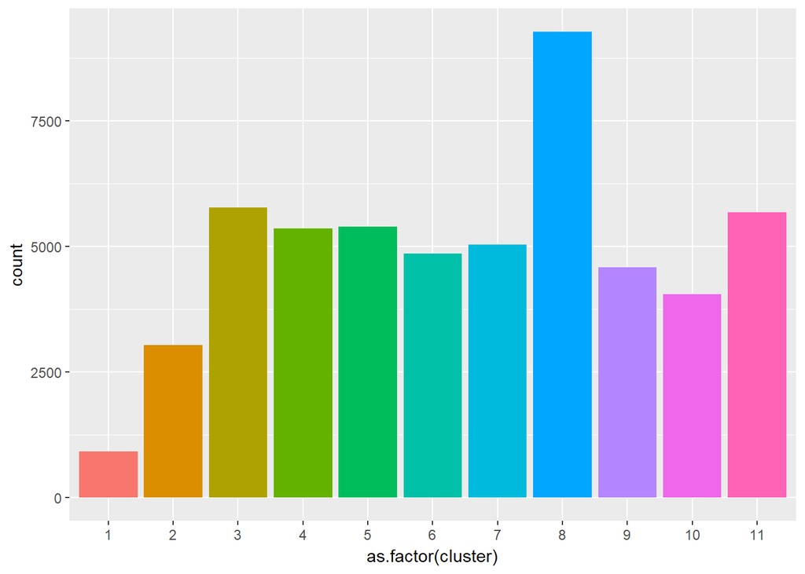

```r
ggplot(data_pred, aes(x = as.factor(cluster)
                      , fill = as.factor(cluster))
       ) +
  geom_bar(show.legend = F)
```

# 7 Does the clustering resolve into decision tree like clutering rules?

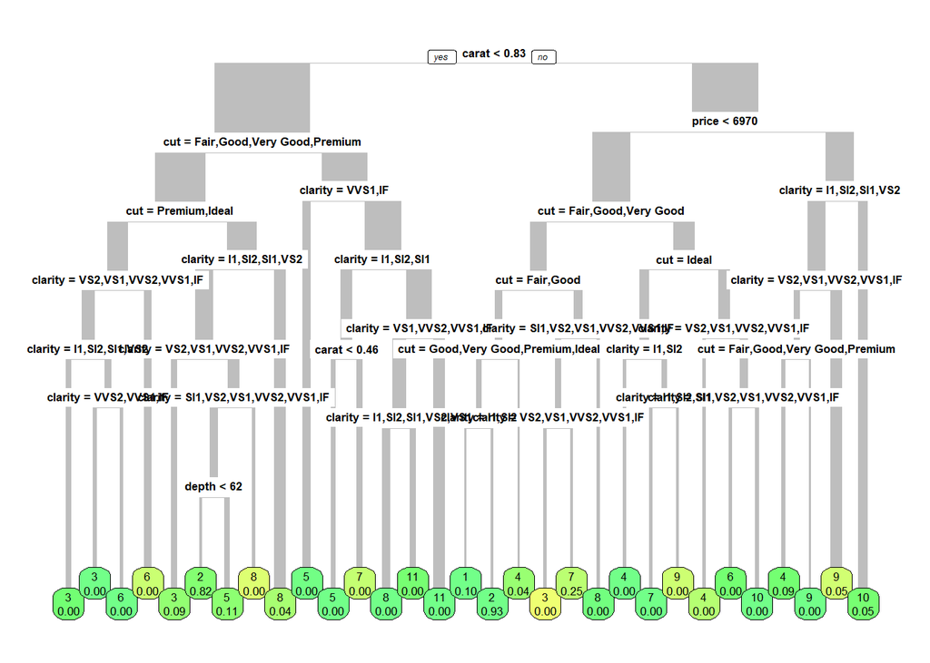

```r
data_pred_tree = data_pred

data_pred_tree$cluster = as.factor(data_pred_tree$cluster)

m_tree = rpart::rpart(cluster~.-map_loc
                      , data_pred_tree
                      , maxdepth = 30)

rpart.plot::prp(m_tree
                  , branch.type   = 5
                  , box.palette   ="RdYlGn"
                  , faclen        = 0
                  , extra         = 6
                  , fallen.leaves = T
                  , tweak         = 2
                  #, gap           = input$gap
                  #, space         = input$space
                  )
```

```r
# add node numbers to data
data_pred_tree$node = m_tree$where

# predicted class for each node
m_tree$frame$node = 1:nrow(m_tree$frame)

data_pred_tree =  data_pred_tree %>%
  left_join( select(m_tree$frame,node, yval) )%>%
  mutate( pred_true = ifelse( yval == cluster, 1,0))
data_sum = data_pred_tree %>%
  group_by(node,yval)%>%
  summarise( prop = sum(pred_true)/n()
             ,n   = n() )
data_sum
```

| node | yval | prop | n |
| --- | --- | --- | --- |
| 6 | 3 | 0.8806941 | 1844 |
| 8 | 3 | 0.9410396 | 1289 |
| 9 | 6 | 1.0000000 | 1176 |
| 10 | 6 | 0.6388130 | 2561 |
| 13 | 3 | 0.7725096 | 2088 |
| 16 | 2 | 0.8153446 | 769 |
| 17 | 5 | 0.6537251 | 1906 |
| 18 | 8 | 0.5761144 | 1189 |
| 19 | 8 | 0.7558140 | 3956 |
| 21 | 5 | 0.7726027 | 2920 |
| 24 | 5 | 0.7738330 | 1521 |
| 25 | 7 | 0.6583371 | 2201 |
| 28 | 8 | 0.9996206 | 2636 |
| 29 | 11 | 0.9178280 | 2081 |
| 30 | 11 | 0.9991989 | 3745 |
| 36 | 1 | 0.8559738 | 611 |
| 37 | 2 | 0.9308462 | 1099 |
| 38 | 4 | 0.7310606 | 792 |
| 41 | 3 | 0.4866732 | 1013 |
| 42 | 7 | 0.6867470 | 1079 |
| 43 | 8 | 0.9792648 | 1061 |
| 46 | 4 | 0.9065657 | 1188 |
| 48 | 7 | 0.9963470 | 1095 |
| 49 | 9 | 0.6334842 | 884 |
| 51 | 4 | 0.6485281 | 1121 |
| 53 | 6 | 0.9267311 | 1242 |
| 54 | 10 | 0.5778927 | 1547 |
| 58 | 4 | 0.8420290 | 1380 |
| 59 | 9 | 0.9987013 | 770 |
| 60 | 9 | 0.6245440 | 3838 |
| 61 | 10 | 0.5305572 | 3338 |

```r
data_sum = data_pred_tree %>%
  summarise( prop = sum(pred_true)/n()
             ,n   = n() )
data_sum
```

| prop | n |
| --- | --- |
| 0.778198 | 53940 |

We can resolve the clusters derived from the SOM map fairly decently to a set of clustering rules. It however seems that the clustering broders are not a 100% sharp and that there seems to be some fuzzyness regarding towards which location on a map a particular neuron (observation) migrates to.